```python
# ensure we meet standard of 'executable code'
print("Hello world!")
```

```
Hello world!
```

We can confirm that the Jupyter Notebook is, in fact, working and that we have met the bare minimum standards for submission.

# Project Update – Quantum Error Correction

## Phil Noel, Alaisha Sharma, Nicolas Weninger

### 16/04/18

Our goal in the initial stages of this project was to better understand error correction and the scope of our project. We all read the paper “Quantum Error Correction for Beginners” as well as sections of the chapter on quantum error correction in Mike & Ike. This has given us a better conceptual understanding of quantum error correction and how larger, more complex circuits can be constructed to deal with multiple errors or combinations of the various types of errors (bit flip, phase, etc.) on multiple qubits.

Unfortunately, due to a combination of midterms, other final projects, penultimate/ultimate problem sets, and preparation for final exams, the three of us have not been able to spend much time at all on our project so far. We definitely want to tackle more of the scope and will aim to at least implement the 5-qubit and 9-qubit circuits outlined in “Quantum Error Correction for Beginners.” After implementing these, we will also run them on IMB Q and hopefully be able to compare the results. This should give us a baseline from which to attempt implementing error correction with the Deutsch-Jozsa algorithm.

```python
import numpy as np
from qiskit import QuantumProgram
import Qconfig
from qiskit.tools.visualization import plot_histogram, plot_state
```

```python
Q_program = QuantumProgram()
Q_program.set_api(Qconfig.APItoken, Qconfig.config['url']) # set the APIToken and API url
```

```python
# define program
qp1 = QuantumProgram()
n = 5  # number of qubits
q = qp1.create_quantum_register("q", n) # quantum register
c = qp1.create_classical_register("c", n) # classical register

# create circuit: BIT FLIP DETECTION
SimpleErrorBit1 = qp1.create_circuit("SimpleErrorBit1", [q], [c])
SimpleErrorBit2 = qp1.create_circuit("SimpleErrorBit2", [q], [c])
```

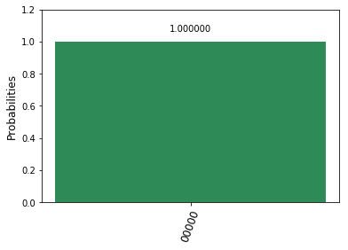

```python
# add gates

# Ancilla
SimpleErrorBit1.cx(q[2],q[4])
SimpleErrorBit1.cx(q[3],q[4])

# measure
SimpleErrorBit1.measure(q[4], c[4])

# execute the circuit
results = qp1.execute("SimpleErrorBit1")

# plot the measurement results.
plot_histogram(results.get_counts("SimpleErrorBit1"))
```

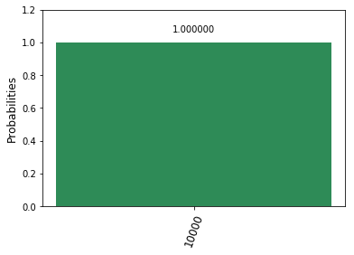

```python
# add gates
# introduce bit flip on q[2]
SimpleErrorBit2.x(q[2])

# Ancilla
SimpleErrorBit2.cx(q[2],q[4])
SimpleErrorBit2.cx(q[3],q[4])

# measure
SimpleErrorBit2.measure(q[4], c[4])

# execute the circuit
results = qp1.execute("SimpleErrorBit2")

# plot the measurement results.
plot_histogram(results.get_counts("SimpleErrorBit2"))
```

The Ancilla qubit indicates that an error has been detected.

```python
# define program
qp2 = QuantumProgram()
n = 5  # number of qubits
q = qp2.create_quantum_register("q", n) # quantum register
c = qp2.create_classical_register("c", n) # classical register

# create circuit: PHASE FLIP DETECTION
SimpleErrorPhase1 = qp2.create_circuit("SimpleErrorPhase1", [q], [c])
SimpleErrorPhase2 = qp2.create_circuit("SimpleErrorPhase2", [q], [c])
```

[figure not shown]

```python
# add gates
# Hademard Basis
SimpleErrorPhase1.h(q[2])
SimpleErrorPhase1.h(q[3])

# Ancilla
SimpleErrorPhase1.cx(q[2],q[4])
SimpleErrorPhase1.cx(q[3],q[4])

# Reverse Hademard Basis
SimpleErrorPhase1.h(q[2])
SimpleErrorPhase1.h(q[3])

# measure
SimpleErrorPhase1.measure(q[4], c[4])

# execute the circuit
results = qp2.execute("SimpleErrorPhase1")

# plot the measurement results.
plot_histogram(results.get_counts("SimpleErrorPhase1"))
```

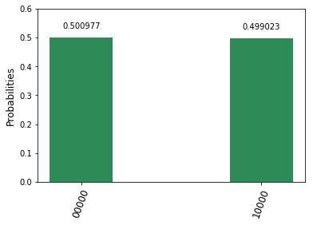

```python
# add gates

# Hademard Basis
SimpleErrorPhase2.h(q[2])
SimpleErrorPhase2.h(q[3])

# error
SimpleErrorPhase2.z(q[2])

# Ancilla
SimpleErrorPhase2.cx(q[2],q[4])
SimpleErrorPhase2.cx(q[3],q[4])

# Reverse Hademard Basis
SimpleErrorPhase2.h(q[2])
SimpleErrorPhase2.h(q[3])

# measure
SimpleErrorPhase2.measure(q[4], c[4])

# execute the circuit
results = qp2.execute("SimpleErrorPhase2")

# plot the measurement results.
plot_histogram(results.get_counts("SimpleErrorPhase2"))
```

We are still somewhat confused about how phase error detection works and will be discussing with Kirkland House tutors who do photonics research as PhD-candidates at MIT to better explain the concepts in Devitt et al.